# TreeMix

Mar Llaberia-Robledillo

2/6/2022

# Alpine and Arctic species

Treemix assumes unlinked SNPs and requires a special input format. I will use a script that generates this input file (`vcf2treemix.sh`) from a vcf and a clust file, which is a file that provides the information on which sample belongs to which taxon.

The clust file contains three columns, whereby the first and the second column indicate the name of the individual, and the third column indicates the taxon name. We can thus easily generate the clust file from our .pop file that we generated previously.

#### Removing species with less than 10 individuals/samples and creating the .clust file

```r
poptable <- read.table('~/cophyhopa/data/popmap.txt',
                       col.names = c('sample', 'group', 'pop', 'lake'))

poptable <- poptable[-which(poptable[,3] == "C.alpinus"), ]
poptable <- poptable[-which(poptable[,3] == "C.alpinus/C.steinmanni"), ]
poptable <- poptable[-which(poptable[,3] == "C.brienzii"), ]
poptable <- poptable[-which(poptable[,3] == "C.fatioi/C.albellus"), ]
poptable <- poptable[-which(poptable[,3] == "C.brienzii/C.fatioi"), ]

poptable$lake <- NULL
poptable$group <- poptable$sample

write.table(poptable, file = '~/cophyhopa/results/2022-06-02/TREE/TREE.clust', quote = FALSE,
            row.names = FALSE, col.names = FALSE)

write.table(poptable[,1], file = '~/cophyhopa/results/2022-06-02/TREE/ALL.txt', quote = FALSE,
            row.names = FALSE, col.names = FALSE)
```

#### Data selecting and filtering

```bash
# Create the vcf.gz file (remove the hybrids and zip vcf)
VCF='/gata/mar/cophyhopa/results/2022-04-22/assem2_outfiles/assem2.vcf'
FILE=TREE
if [ ! -e ./TREE/$FILE.vcf.gz ]; then
   vcftools --vcf $VCF \
            --out dirty \
            --keep ./TREE/ALL.txt \
            --remove ~/cophyhopa/results/2022-05-04/TheWorst.txt \
            --recode \
            --recode-INFO-all
   vcftools --vcf dirty.recode.vcf \
            --out $FILE \
            --thin 500 \
            --remove-indels \
            --mac 2 \
            --max-alleles 2 \
            --max-meanDP 1000 \
            --max-missing 1 \
            --stdout \
            --recode --recode-INFO-all \
            | gzip > ./TREE/$FILE.vcf.gz
fi
if [ -e dirty.recode.vcf ]; then rm dirty.recode.vcf; fi
```

#### Generate the INPUT file and execute TreeMix

```bash
# Download the script that generates the input file and execute it
#wget https://github.com/speciationgenomics/scripts/blob/master/vcf2treemix.sh
# Thom Nelson's adaptation of Tomaz Berisa's script to convert plink clustered allele frequencies to treemix format
#   (https://bitbucket.org/nygcresearch/treemix/downloads/)

FILE=TREE
./vcf2treemix.sh ./TREE/$FILE.vcf.gz ./TREE/$FILE.clust

# Execute the treemix command (no-root & no-m)
treemix -i ./TREE/$FILE.treemix.frq.gz \
        -bootstrap \
        -o ./TREE/out${FILE}_1
```

#### Plot the tree

I have downloaded an R script (https://speciationgenomics.github.io/Treemix/) to display the output tree

```r
setwd("~/cophyhopa/results/2022-06-02")
library(RColorBrewer)
library(R.utils)
source("~/cophyhopa/results/2022-06-02/plotting_funcs.R") # here you need to add the path

plot_tree("TREE/outTREE_1", mbar = FALSE, scale = FALSE, plus = 0.01)
```

[output not shown]

## Adding parameters to the basic tree

There are two important parameters. The first is rooting the tree assuming the Arctic species as a outgroup, since it seems that these species are more differentiated of Alpine sp. The second is to test the optimal number of migration events (seems that has to be similar to the k obtained from admixture).

#### Create the .clust file

```r
poptable <- read.table('~/cophyhopa/results/2022-06-02/TREE/TREE.clust',
                       col.names = c('sample', 'sample', 'pop'))
poptable[,3] <- as.character(poptable[,3])
poptable[which(poptable[,3] == "D"), 3] <- "Arctic"
poptable[which(poptable[,3] == "P"), 3] <- "Arctic"
poptable[which(poptable[,3] == "L"), 3] <- "Arctic"
write.table(poptable, file = '~/cophyhopa/results/2022-06-02/TREE/TREE.clust', quote = FALSE,
            row.names = FALSE, col.names = FALSE)
```

#### Generate the INPUT file and execute TreeMix

#### Plot the tree

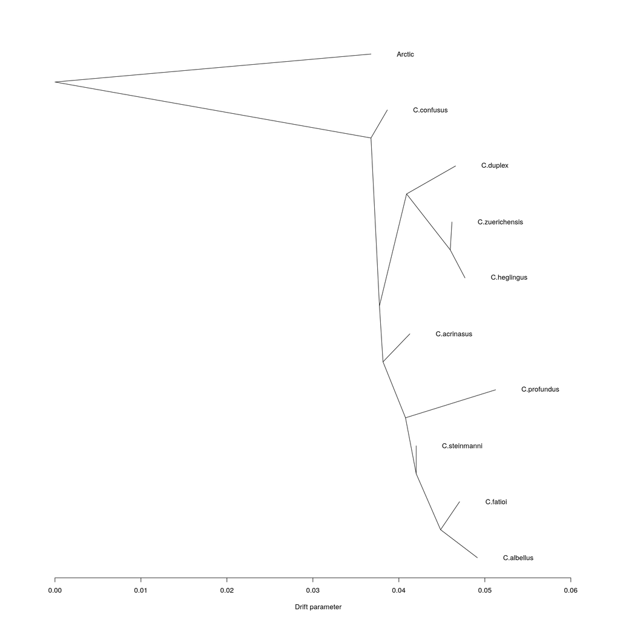

```r
setwd("~/cophyhopa/results/2022-06-02")
library(RColorBrewer)
library(R.utils)
source("~/cophyhopa/results/2022-06-02/plotting_funcs.R") # here you need to add the path

plot_tree("TREE/outTREE.0", mbar = FALSE, scale = FALSE, plus = 0.01)
```

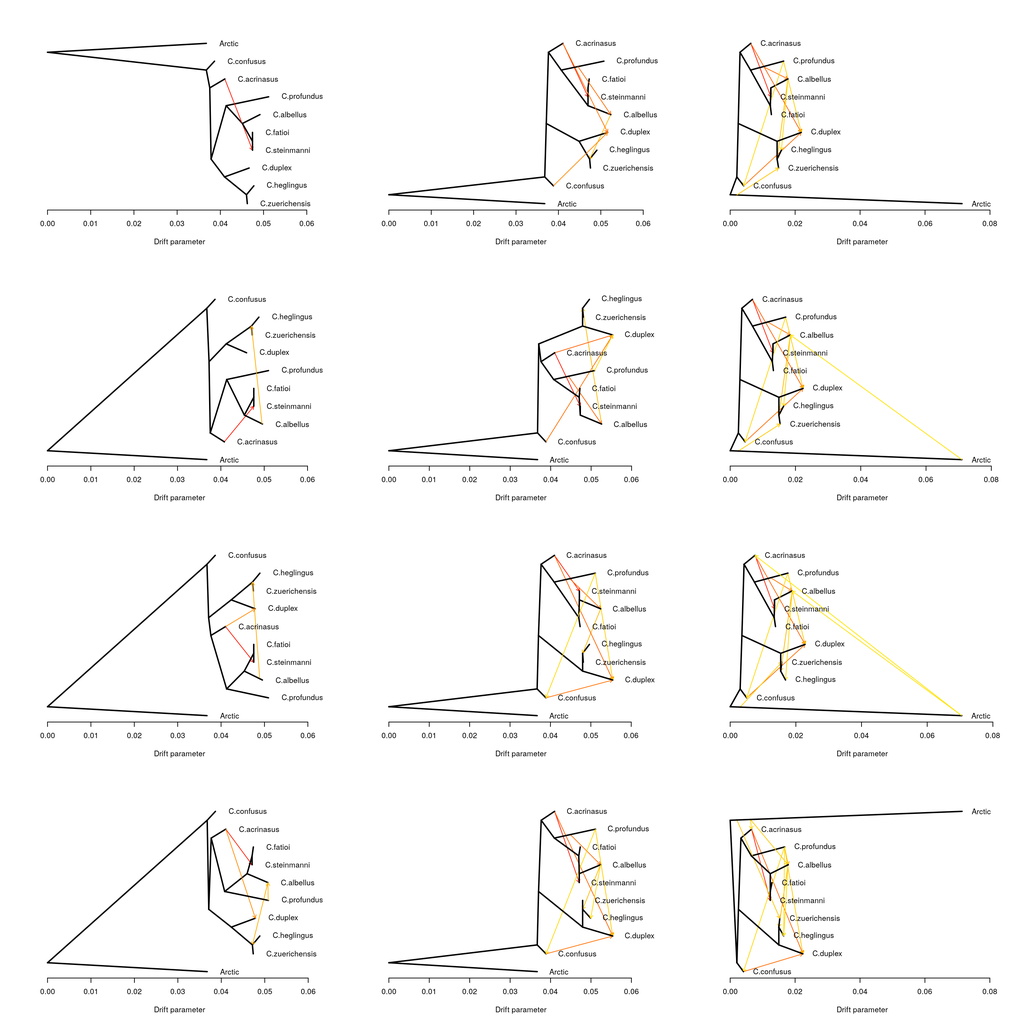

```r
par(mfcol = c(4, 3))
plot_tree("TREE/outTREE.1", mbar = FALSE, scale = FALSE, lwd = 2)
plot_tree("TREE/outTREE.2", mbar = FALSE, scale = FALSE, lwd = 2)
plot_tree("TREE/outTREE.3", mbar = FALSE, scale = FALSE, lwd = 2)
plot_tree("TREE/outTREE.4", mbar = FALSE, scale = FALSE, lwd = 2)
plot_tree("TREE/outTREE.5", mbar = FALSE, scale = FALSE, lwd = 2)
plot_tree("TREE/outTREE.6", mbar = FALSE, scale = FALSE, lwd = 2)
plot_tree("TREE/outTREE.7", mbar = FALSE, scale = FALSE, lwd = 2)
plot_tree("TREE/outTREE.8", mbar = FALSE, scale = FALSE, lwd = 2)
plot_tree("TREE/outTREE.9", mbar = FALSE, scale = FALSE, lwd = 2)
plot_tree("TREE/outTREE.10", mbar = FALSE, scale = FALSE, lwd = 2)
plot_tree("TREE/outTREE.11", mbar = FALSE, scale = FALSE, lwd = 2)
plot_tree("TREE/outTREE.12", mbar = FALSE, scale = FALSE, lwd = 2)
```

# Alpine species

Treemix assumes unlinked SNPs and requires a special input format. I will use a script that generates this input file (`vcf2treemix.sh`) from a vcf and a clust file, which is a file that provides the information on which sample belongs to which taxon.

The clust file contains three columns, whereby the first and the second column indicate the name of the individual, and the third column indicates the taxon name. We can thus easily generate the clust file from our .pop file that we generated previously.

#### Removing species with less than 10 individuals/samples and creating the .clust file

```r
poptable <- read.table('~/cophyhopa/data/popmap.txt',
                       col.names = c('sample', 'group', 'pop', 'lake'))

poptable <- poptable[-which(poptable[,3] == "C.alpinus"), ]
poptable <- poptable[-which(poptable[,3] == "C.alpinus/C.steinmanni"), ]
poptable <- poptable[-which(poptable[,3] == "C.brienzii"), ]
poptable <- poptable[-which(poptable[,3] == "C.fatioi/C.albellus"), ]
poptable <- poptable[-which(poptable[,3] == "C.brienzii/C.fatioi"), ]
poptable <- poptable[-which(poptable[,3] == "P"), ]
poptable <- poptable[-which(poptable[,3] == "D"), ]
poptable <- poptable[-which(poptable[,3] == "L"), ]

poptable$lake <- NULL
poptable$group <- poptable$sample

write.table(poptable, file = '~/cophyhopa/results/2022-06-02/ALP_TREE/ALP_TREE.clust', quote = FALSE,
            row.names = FALSE, col.names = FALSE)

write.table(poptable[,1], file = '~/cophyhopa/results/2022-06-02/ALP_TREE/ALP.txt', quote = FALSE,
            row.names = FALSE, col.names = FALSE)
```

#### Data selecting and filtering

#### Generate the INPUT file and execute TreeMix

#### Plot the tree

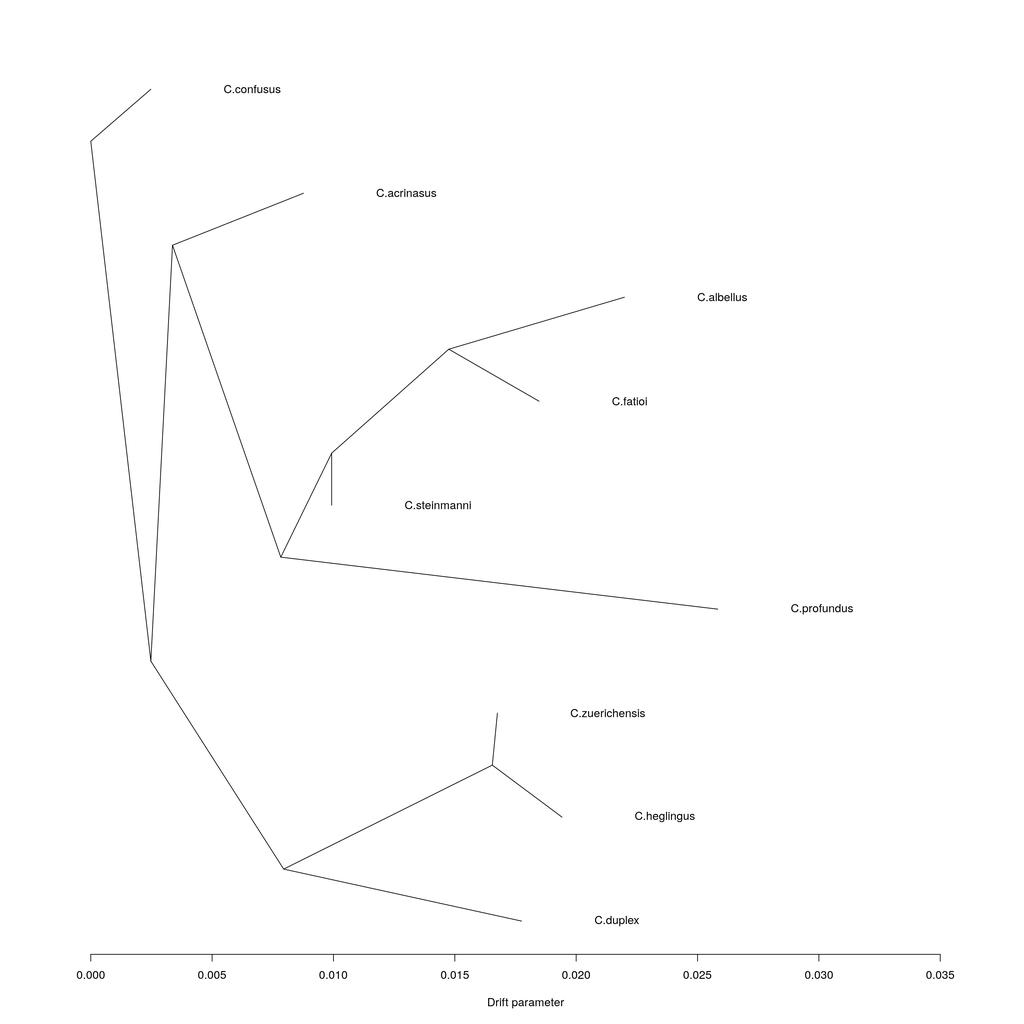

```r
setwd("~/cophyhopa/results/2022-06-02")
library(RColorBrewer)
library(R.utils)
source("~/cophyhopa/results/2022-06-02/plotting_funcs.R") # here you need to add the path

plot_tree("ALP_TREE/outALP_TREE.0", mbar = FALSE, scale = FALSE, plus = 0.01)
```

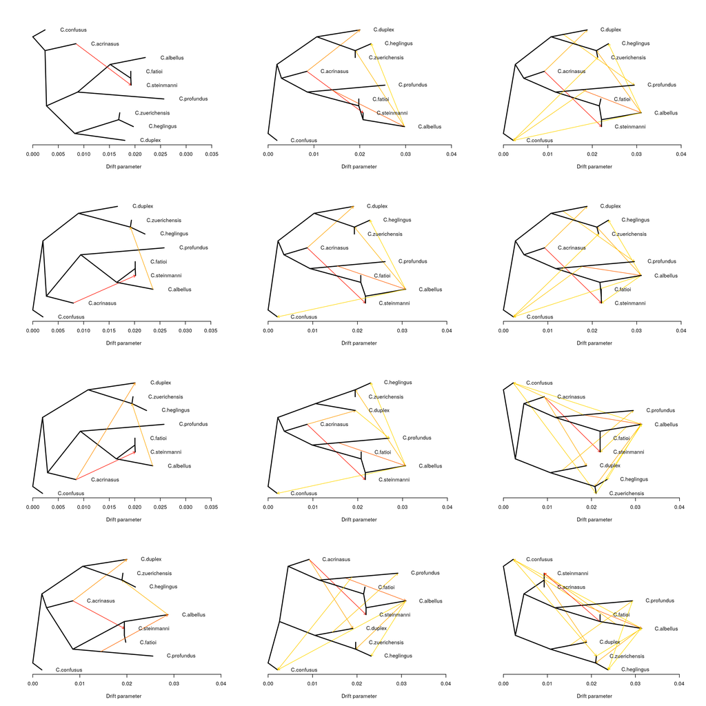

```r
par(mfcol = c(4, 3))
plot_tree("ALP_TREE/outALP_TREE.1", mbar = FALSE, scale = FALSE, lwd = 2)
plot_tree("ALP_TREE/outALP_TREE.2", mbar = FALSE, scale = FALSE, lwd = 2)
plot_tree("ALP_TREE/outALP_TREE.3", mbar = FALSE, scale = FALSE, lwd = 2)
plot_tree("ALP_TREE/outALP_TREE.4", mbar = FALSE, scale = FALSE, lwd = 2)
plot_tree("ALP_TREE/outALP_TREE.5", mbar = FALSE, scale = FALSE, lwd = 2)
plot_tree("ALP_TREE/outALP_TREE.6", mbar = FALSE, scale = FALSE, lwd = 2)
plot_tree("ALP_TREE/outALP_TREE.7", mbar = FALSE, scale = FALSE, lwd = 2)
plot_tree("ALP_TREE/outALP_TREE.8", mbar = FALSE, scale = FALSE, lwd = 2)
plot_tree("ALP_TREE/outALP_TREE.9", mbar = FALSE, scale = FALSE, lwd = 2)
plot_tree("ALP_TREE/outALP_TREE.10", mbar = FALSE, scale = FALSE, lwd = 2)
plot_tree("ALP_TREE/outALP_TREE.11", mbar = FALSE, scale = FALSE, lwd = 2)
plot_tree("ALP_TREE/outALP_TREE.12", mbar = FALSE, scale = FALSE, lwd = 2)
```